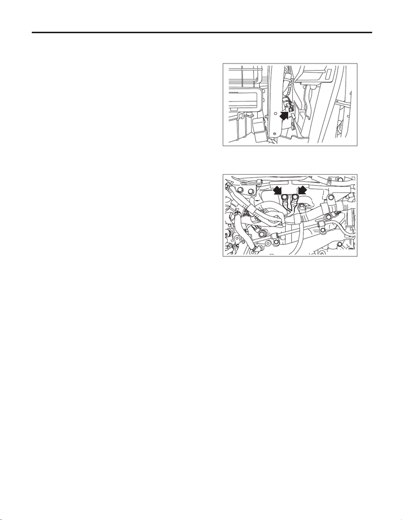

EN(w/o STI)(diag)-6

General Description

ENGINE (DIAGNOSTICS)

3. General Description

A: CAUTION

1) Airbag system wiring harness is routed near the

ECM, main relay and fuel pump relay.

CAUTION:

• Do not use electrical test equipment on the

airbag system circuits.

• Be careful not to damage the airbag system

wiring harness when servicing the ECM, TCM,

main relay and fuel pump relay.

2) Never connect the battery in reverse polarity.

Doing so will damage the ECM instantly, and other

parts will also be damaged.

3) Do not disconnect the battery terminals while the

engine is running. A large counter electromotive

force will be generated in the generator, and this

voltage may damage electronic parts such as ECM

etc.

4) When disconnecting the connectors of the elec-

trical components, always be sure to turn the igni-

tion switch to OFF. Perform the Clear Memory

Mode after connecting the connectors. <Ref. to

EN(w/o STI)(diag)-61, Clear Memory Mode.>

5) When measuring the voltage or resistance of in-

dividual sensor or all electrical control modules,

use a tapered pin with a diameter of 0.6 mm (0.024

in) or less and touch it to the tip of terminal. Never

insert the tapered pin into the terminal because it

deforms inside which may lead to malfunction.

CAUTION:

When replacing the ECM, be careful not to use

the ECM of wrong specification to avoid any

damage on the fuel injection system.

NOTE:

When replacing the ECM of the models with immo-

bilizer, immobilizer system must be registered. For

detailed procedures, refer to “REGISTRATION

MANUAL FOR IMMOBILIZER”.

6) The ECM connector is waterproof. When mea-

suring the ECM connector terminal voltages, or the

resistance between the ECM connector terminals,

use the ST.

ST 18460AA030 CHECK BOARD

7) Take care not to allow water to get into the con-

nectors when servicing or washing the vehicle in

rainy weather. Avoid exposure to water even if the

connectors are waterproof.

8) Use the ground terminal of the bulkhead harness

for the grounding point when measuring voltage

and resistance inside the passenger compartment.

9) Use the engine ground terminal or engine as-

sembly for the grounding point when measuring the

voltage and resistance in engine compartment.

10) All parts related to the engine control system

are precision parts. Do not drop or otherwise apply

impact. Do not reuse the parts that are dropped ac-

cidentally.

11) Do not connect the wiring of electrical parts di-

rectly to the battery terminals. It may cause errone-

ous operation of the charge control, leading to early

deterioration of the battery or discharged battery.

12) Observe the following cautions when installing

a radio in vehicle.

CAUTION:

• The antenna must be kept as far apart as pos-

sible from the ECM. <Ref. to EN(w/o STI)(diag)-

9, CONTROL MODULE, LOCATION, Electrical

Component Location.>

• The antenna feeder must be placed as far

apart as possible from the ECM and engine

control system harness.

• Carefully adjust the antenna for correct

matching.

• When mounting a large power type radio, pay

special attention to the three items mentioned

above.

• Incorrect installation of the radio may affect

the operation of ECM.

EN-10205

EN-09705

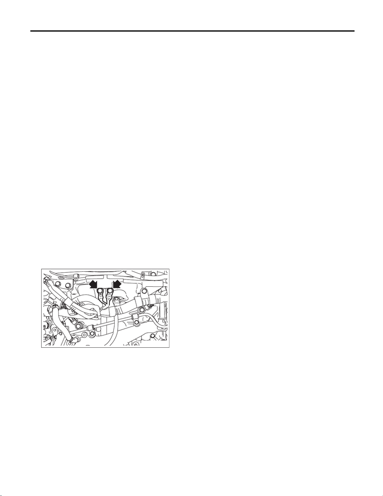

EN(w/o STI)(diag)-7

General Description

ENGINE (DIAGNOSTICS)

13) When disconnecting the fuel hose, be sure to

release the fuel pressure beforehand. <Ref. to

FU(w/o STI)-146, RELEASING OF FUEL PRES-

SURE, PROCEDURE, Fuel.>

14) Warning lights may illuminate when performing

driving test with jacked-up or lifted-up condition, but

this is not a system malfunction. The reason for this

is the rotating speed difference between the front

and rear wheels. When engine control system diag-

nosis is finished, perform the VDC memory clear-

ance procedure of self-diagnosis function. <Ref. to

VDC(diag)-23, Clear Memory Mode.>

B: INSPECTION

Before performing diagnostics, check the following

item which might affect engine problems.

1. BATTERY

1) Measure the battery voltage and specific gravity

of the electrolyte.

Standard voltage: 12 V

Specific gravity: 1.260 or more

2) Check the condition of the main and other fuses,

and harnesses and connectors. Also check for

proper grounding.

2. ENGINE GROUND

Make sure that the engine ground terminal has no

contamination, corrosion or looseness and is prop-

erly connected to the engine.

C: NOTE

• The on-board diagnostic (OBD) system detects

and indicates a fault in various inputs and outputs

of the complex electronic control. Malfunction indi-

cator light in the combination meter indicates oc-

currence of a fault or trouble.

• Further, against any failure of sensors that would

cause the vehicle to stop running, the fail-safe func-

tion is provided to ensure the minimal drivability.

• The OBD system incorporated with the vehicles

within this type of engine complies with OBD-II reg-

ulations. The OBD system monitors the compo-

nents and the system malfunction listed in “Engine

Section” which affects on emissions.

• When the system decides that a malfunction oc-

curs, malfunction indicator light illuminates. At the

same time of the malfunction indicator light illumi-

nation or blinking, a DTC and a freeze frame en-

gine conditions are stored into on-board computer.

• The OBD system stores freeze frame engine

condition data (engine load, engine coolant tem-

perature, fuel trim, engine speed and vehicle

speed, etc.) into on-board computer when it detects

a malfunction.

• Freeze frame engine condition data are stored

until the DTCs are cleared. However when such

malfunctions as fuel trim fault and misfire are de-

tected with the freeze frame engine condition data

stored, they are rewritten into those related to the

fuel trim fault and misfire.

• When the malfunction does not occur again for

three consecutive driving cycles*, malfunction indi-

cator light is turned off, but DTC remains at on-

board computer.

*: One driving cycle means the period between the

ignition switch ON and the ignition switch OFF after

driving.

• When performing diagnosis, connect the Subaru

Select Monitor or general scan tool to the vehicle.

EN-09705

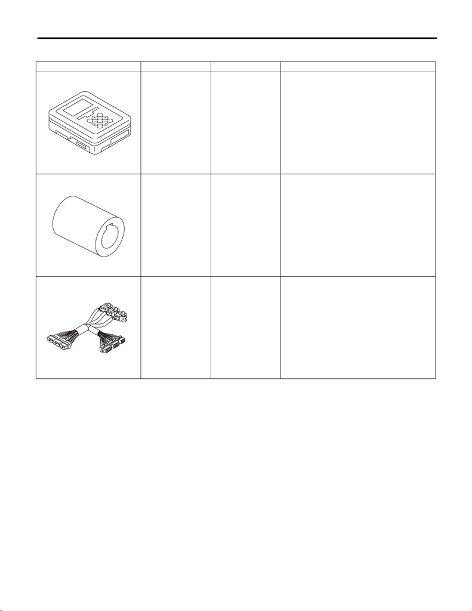

EN(w/o STI)(diag)-8

General Description

ENGINE (DIAGNOSTICS)

D: PREPARATION TOOL

ILLUSTRATION TOOL NUMBER DESCRIPTION REMARKS

1B022XU0 SUBARU SELECT

MONITOR III KIT

Used for troubleshooting the electrical system.

18252AA000 CRANKSHAFT

SOCKET

Used for rotating crankshaft.

18460AA030 CHECK BOARD Used for measuring the ECM terminal voltage.

ST1B022XU0

ST18252AA000

ST18460AA030